# Risk Factor Analysis

## Outcome Variable

**Outcome Variable:** whz

## Predictor Variables

**Intervention Variable:** mwtkg

**Adjustment Set:**

- arm
- W_mage
- meducyrs
- feducyrs
- hhwealth_quart
- W_nchldlt5
- brthmon
- W_parity
- impfloor
- impsan
- safeh20
- W_gagebrth
- W_birthwt
- W_birthlen
- vagbrth
- parity
- delta_W_mage
- delta_meducyrs
- delta_feducyrs
- delta_hhwealth_quart
- delta_W_nchldlt5
- delta_brthmon
- delta_W_parity
- delta_impfloor
- delta_impsan
- delta_safeh20
- delta_W_gagebrth
- delta_W_birthwt
- delta_W_birthlen
- delta_vagbrth
- delta_parity

## Stratifying Variables

The analysis was stratified on these variable(s):

- agecat
- studyid
- country

## Data Summary

| agecat | studyid | country | mwtkg | n_cell | n | outcome_variable |
| --- | --- | --- | --- | --- | --- | --- |
| 6 months | ki0047075b-MAL-ED | BANGLADESH | >=58 kg | 46 | 241 | whz |
| 6 months | ki0047075b-MAL-ED | BANGLADESH | <52 kg | 154 | 241 | whz |
| 6 months | ki0047075b-MAL-ED | BANGLADESH | [52-58) kg | 41 | 241 | whz |
| 6 months | ki0047075b-MAL-ED | BRAZIL | >=58 kg | 137 | 208 | whz |
| 6 months | ki0047075b-MAL-ED | BRAZIL | <52 kg | 37 | 208 | whz |
| 6 months | ki0047075b-MAL-ED | BRAZIL | [52-58) kg | 34 | 208 | whz |
| 6 months | ki0047075b-MAL-ED | INDIA | >=58 kg | 40 | 235 | whz |
| 6 months | ki0047075b-MAL-ED | INDIA | <52 kg | 146 | 235 | whz |
| 6 months | ki0047075b-MAL-ED | INDIA | [52-58) kg | 49 | 235 | whz |
| 6 months | ki0047075b-MAL-ED | NEPAL | >=58 kg | 79 | 236 | whz |
| 6 months | ki0047075b-MAL-ED | NEPAL | <52 kg | 75 | 236 | whz |
| 6 months | ki0047075b-MAL-ED | NEPAL | [52-58) kg | 82 | 236 | whz |
| 6 months | ki0047075b-MAL-ED | PERU | >=58 kg | 100 | 272 | whz |
| 6 months | ki0047075b-MAL-ED | PERU | <52 kg | 107 | 272 | whz |
| 6 months | ki0047075b-MAL-ED | PERU | [52-58) kg | 65 | 272 | whz |
| 6 months | ki0047075b-MAL-ED | SOUTH AFRICA | >=58 kg | 179 | 249 | whz |
| 6 months | ki0047075b-MAL-ED | SOUTH AFRICA | <52 kg | 29 | 249 | whz |
| 6 months | ki0047075b-MAL-ED | SOUTH AFRICA | [52-58) kg | 41 | 249 | whz |
| 6 months | ki0047075b-MAL-ED | TANZANIA, UNITED REPUBLIC OF | >=58 kg | 94 | 247 | whz |
| 6 months | ki0047075b-MAL-ED | TANZANIA, UNITED REPUBLIC OF | <52 kg | 95 | 247 | whz |
| 6 months | ki0047075b-MAL-ED | TANZANIA, UNITED REPUBLIC OF | [52-58) kg | 58 | 247 | whz |
| 6 months | ki1000304b-SAS-CompFeed | INDIA | >=58 kg | 103 | 1329 | whz |
| 6 months | ki1000304b-SAS-CompFeed | INDIA | <52 kg | 1011 | 1329 | whz |
| 6 months | ki1000304b-SAS-CompFeed | INDIA | [52-58) kg | 215 | 1329 | whz |
| 6 months | ki1017093-NIH-Birth | BANGLADESH | >=58 kg | 71 | 537 | whz |
| 6 months | ki1017093-NIH-Birth | BANGLADESH | <52 kg | 385 | 537 | whz |
| 6 months | ki1017093-NIH-Birth | BANGLADESH | [52-58) kg | 81 | 537 | whz |
| 6 months | ki1017093b-PROVIDE | BANGLADESH | >=58 kg | 108 | 602 | whz |
| 6 months | ki1017093b-PROVIDE | BANGLADESH | <52 kg | 385 | 602 | whz |
| 6 months | ki1017093b-PROVIDE | BANGLADESH | [52-58) kg | 109 | 602 | whz |

[output cut: 63 more lines]

The following strata were considered:

- agecat: 24 months, studyid: ki0047075b-MAL-ED, country: BANGLADESH
- agecat: 24 months, studyid: ki0047075b-MAL-ED, country: BRAZIL
- agecat: 24 months, studyid: ki0047075b-MAL-ED, country: INDIA
- agecat: 24 months, studyid: ki0047075b-MAL-ED, country: NEPAL
- agecat: 24 months, studyid: ki0047075b-MAL-ED, country: PERU
- agecat: 24 months, studyid: ki0047075b-MAL-ED, country: SOUTH AFRICA
- agecat: 24 months, studyid: ki0047075b-MAL-ED, country: TANZANIA, UNITED REPUBLIC OF
- agecat: 24 months, studyid: ki1017093-NIH-Birth, country: BANGLADESH
- agecat: 24 months, studyid: ki1017093b-PROVIDE, country: BANGLADESH
- agecat: 24 months, studyid: ki1017093c-NIH-Crypto, country: BANGLADESH
- agecat: 24 months, studyid: ki1066203-TanzaniaChild2, country: TANZANIA, UNITED REPUBLIC OF
- agecat: 24 months, studyid: ki1119695-PROBIT, country: BELARUS
- agecat: 24 months, studyid: ki1126311-ZVITAMBO, country: ZIMBABWE
- agecat: 24 months, studyid: ki1148112-LCNI-5, country: MALAWI
- agecat: 24 months, studyid: kiGH5241-JiVitA-3, country: BANGLADESH
- agecat: 6 months, studyid: ki0047075b-MAL-ED, country: BANGLADESH
- agecat: 6 months, studyid: ki0047075b-MAL-ED, country: BRAZIL
- agecat: 6 months, studyid: ki0047075b-MAL-ED, country: INDIA
- agecat: 6 months, studyid: ki0047075b-MAL-ED, country: NEPAL
- agecat: 6 months, studyid: ki0047075b-MAL-ED, country: PERU
- agecat: 6 months, studyid: ki0047075b-MAL-ED, country: SOUTH AFRICA
- agecat: 6 months, studyid: ki0047075b-MAL-ED, country: TANZANIA, UNITED REPUBLIC OF
- agecat: 6 months, studyid: ki1000304b-SAS-CompFeed, country: INDIA
- agecat: 6 months, studyid: ki1017093-NIH-Birth, country: BANGLADESH
- agecat: 6 months, studyid: ki1017093b-PROVIDE, country: BANGLADESH
- agecat: 6 months, studyid: ki1017093c-NIH-Crypto, country: BANGLADESH
- agecat: 6 months, studyid: ki1066203-TanzaniaChild2, country: TANZANIA, UNITED REPUBLIC OF
- agecat: 6 months, studyid: ki1119695-PROBIT, country: BELARUS
- agecat: 6 months, studyid: ki1126311-ZVITAMBO, country: ZIMBABWE
- agecat: 6 months, studyid: ki1148112-LCNI-5, country: MALAWI
- agecat: 6 months, studyid: kiGH5241-JiVitA-3, country: BANGLADESH

### Dropped Strata

Some strata were dropped due to rare outcomes:

- agecat: 24 months, studyid: ki1066203-TanzaniaChild2, country: TANZANIA, UNITED REPUBLIC OF

## Methods Detail

We’re interested in the causal parameters $E[Y_a]$ for all values of $a \in \mathcal{A}$. These parameters represent the mean outcome if, possibly contrary to fact, we intervened to set all units to have $A=a$. Under the randomization and positivity assumptions, these are identified by the statistical parameters $\psi_a=E_W[E_{Y|A,W}(Y|A=a,W)]$. In addition, we’re interested in the mean of $Y$, $E[Y]$ under no intervention (the observed mean). We will estimate these parameters by using SuperLearner to fit the relevant likelihood factors – $E_{Y|A,W}(Y|A=a,W)$ and $p(A=a|W)$, and then updating our likelihood fit using a joint TMLE.

For unadjusted analyses ($W=\{\}$), initial likelihoods were estimated using Lrnr_glm to estimate the simple $E(Y|A)$ and Lrnr_mean to estimate $p(A)$. For adjusted analyses, a small library containing Lrnr_glmnet, Lrnr_xgboost, and Lrnr_mean was used.

Having estimated these parameters, we will then use the delta method to estimate relative risks and attributable risks relative to a prespecified baseline level of $A$.

# Results Detail

## Results Plots

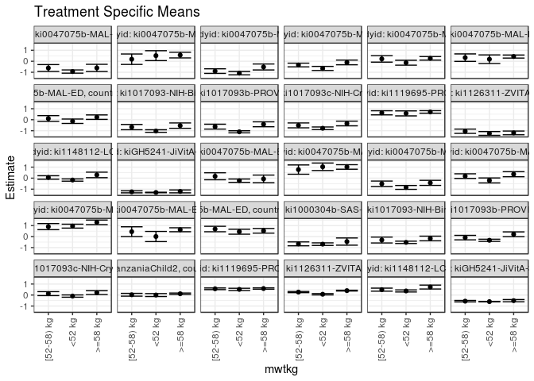

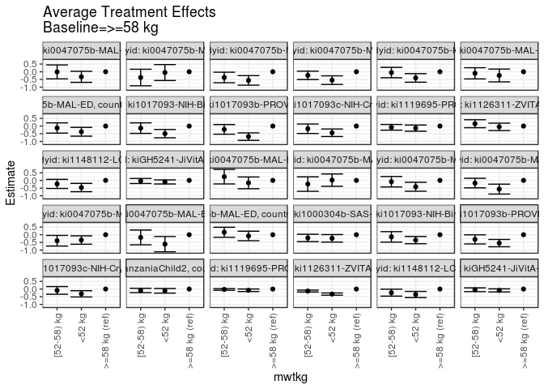

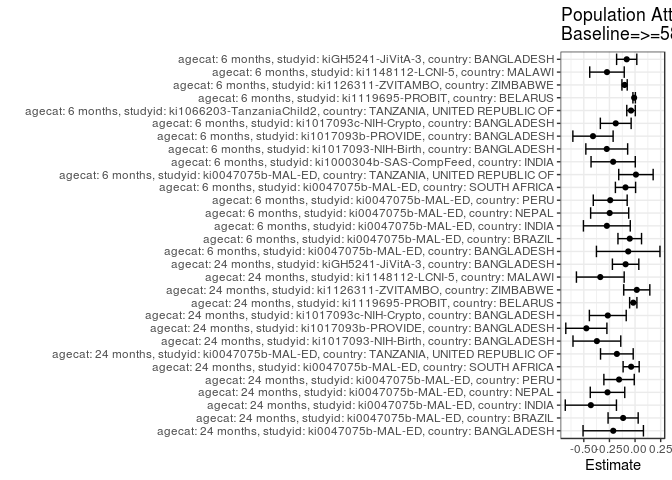

## Results Table

### Parameter: TSM

| agecat | studyid | country | intervention_level | baseline_level | estimate | ci_lower | ci_upper |
| --- | --- | --- | --- | --- | --- | --- | --- |
| 6 months | ki0047075b-MAL-ED | BANGLADESH | >=58 kg | NA | -0.0708009 | -0.4207533 | 0.2791516 |
| 6 months | ki0047075b-MAL-ED | BANGLADESH | <52 kg | NA | -0.2306930 | -0.3826694 | -0.0787165 |
| 6 months | ki0047075b-MAL-ED | BANGLADESH | [52-58) kg | NA | 0.1701839 | -0.1458355 | 0.4862034 |
| 6 months | ki0047075b-MAL-ED | BRAZIL | >=58 kg | NA | 1.0166565 | 0.8113257 | 1.2219873 |
| 6 months | ki0047075b-MAL-ED | BRAZIL | <52 kg | NA | 1.0342825 | 0.6941825 | 1.3743825 |
| 6 months | ki0047075b-MAL-ED | BRAZIL | [52-58) kg | NA | 0.7782469 | 0.3551050 | 1.2013889 |
| 6 months | ki0047075b-MAL-ED | INDIA | >=58 kg | NA | -0.4282186 | -0.6593886 | -0.1970486 |
| 6 months | ki0047075b-MAL-ED | INDIA | <52 kg | NA | -0.8429974 | -1.0199154 | -0.6660794 |
| 6 months | ki0047075b-MAL-ED | INDIA | [52-58) kg | NA | -0.5138644 | -0.7621347 | -0.2655941 |
| 6 months | ki0047075b-MAL-ED | NEPAL | >=58 kg | NA | 0.3581251 | 0.1275452 | 0.5887051 |
| 6 months | ki0047075b-MAL-ED | NEPAL | <52 kg | NA | -0.2084707 | -0.4346705 | 0.0177292 |
| 6 months | ki0047075b-MAL-ED | NEPAL | [52-58) kg | NA | 0.1844197 | -0.0253367 | 0.3941761 |
| 6 months | ki0047075b-MAL-ED | PERU | >=58 kg | NA | 1.2970313 | 1.0893304 | 1.5047321 |
| 6 months | ki0047075b-MAL-ED | PERU | <52 kg | NA | 0.9511480 | 0.7731970 | 1.1290989 |
| 6 months | ki0047075b-MAL-ED | PERU | [52-58) kg | NA | 0.9053076 | 0.6302635 | 1.1803518 |
| 6 months | ki0047075b-MAL-ED | SOUTH AFRICA | >=58 kg | NA | 0.6224088 | 0.4435948 | 0.8012228 |
| 6 months | ki0047075b-MAL-ED | SOUTH AFRICA | <52 kg | NA | 0.0083231 | -0.4543597 | 0.4710058 |
| 6 months | ki0047075b-MAL-ED | SOUTH AFRICA | [52-58) kg | NA | 0.4473738 | 0.0041413 | 0.8906063 |
| 6 months | ki0047075b-MAL-ED | TANZANIA, UNITED REPUBLIC OF | >=58 kg | NA | 0.5276207 | 0.3163463 | 0.7388951 |
| 6 months | ki0047075b-MAL-ED | TANZANIA, UNITED REPUBLIC OF | <52 kg | NA | 0.4468202 | 0.2195547 | 0.6740858 |
| 6 months | ki0047075b-MAL-ED | TANZANIA, UNITED REPUBLIC OF | [52-58) kg | NA | 0.6886321 | 0.4411287 | 0.9361355 |
| 6 months | ki1000304b-SAS-CompFeed | INDIA | >=58 kg | NA | -0.4525003 | -0.7801354 | -0.1248652 |
| 6 months | ki1000304b-SAS-CompFeed | INDIA | <52 kg | NA | -0.6873937 | -0.8037546 | -0.5710329 |
| 6 months | ki1000304b-SAS-CompFeed | INDIA | [52-58) kg | NA | -0.6622940 | -0.8400062 | -0.4845819 |
| 6 months | ki1017093-NIH-Birth | BANGLADESH | >=58 kg | NA | -0.1712093 | -0.3823558 | 0.0399371 |
| 6 months | ki1017093-NIH-Birth | BANGLADESH | <52 kg | NA | -0.5224288 | -0.6282452 | -0.4166125 |
| 6 months | ki1017093-NIH-Birth | BANGLADESH | [52-58) kg | NA | -0.3121712 | -0.5788765 | -0.0454659 |
| 6 months | ki1017093b-PROVIDE | BANGLADESH | >=58 kg | NA | 0.2116717 | -0.0055709 | 0.4289143 |
| 6 months | ki1017093b-PROVIDE | BANGLADESH | <52 kg | NA | -0.3357584 | -0.4337311 | -0.2377858 |
| 6 months | ki1017093b-PROVIDE | BANGLADESH | [52-58) kg | NA | -0.0918996 | -0.2946243 | 0.1108251 |

[output cut: 60 more lines]

### Parameter: E(Y)

| agecat | studyid | country | intervention_level | baseline_level | estimate | ci_lower | ci_upper |
| --- | --- | --- | --- | --- | --- | --- | --- |
| 6 months | ki0047075b-MAL-ED | BANGLADESH | NA | NA | -0.1376763 | -0.2664642 | -0.0088885 |
| 6 months | ki0047075b-MAL-ED | BRAZIL | NA | NA | 0.9648518 | 0.8004118 | 1.1292917 |
| 6 months | ki0047075b-MAL-ED | INDIA | NA | NA | -0.7034149 | -0.8300527 | -0.5767771 |
| 6 months | ki0047075b-MAL-ED | NEPAL | NA | NA | 0.1104308 | -0.0208643 | 0.2417259 |
| 6 months | ki0047075b-MAL-ED | PERU | NA | NA | 1.0548591 | 0.9328922 | 1.1768259 |
| 6 months | ki0047075b-MAL-ED | SOUTH AFRICA | NA | NA | 0.5291499 | 0.3751396 | 0.6831602 |
| 6 months | ki0047075b-MAL-ED | TANZANIA, UNITED REPUBLIC OF | NA | NA | 0.5362213 | 0.4049390 | 0.6675036 |
| 6 months | ki1000304b-SAS-CompFeed | INDIA | NA | NA | -0.6660835 | -0.8034722 | -0.5286949 |
| 6 months | ki1017093-NIH-Birth | BANGLADESH | NA | NA | -0.4474038 | -0.5378167 | -0.3569909 |
| 6 months | ki1017093b-PROVIDE | BANGLADESH | NA | NA | -0.1987071 | -0.2815473 | -0.1158669 |
| 6 months | ki1017093c-NIH-Crypto | BANGLADESH | NA | NA | 0.0297622 | -0.0491685 | 0.1086930 |
| 6 months | ki1066203-TanzaniaChild2 | TANZANIA, UNITED REPUBLIC OF | NA | NA | 0.0780261 | 0.0247830 | 0.1312691 |
| 6 months | ki1119695-PROBIT | BELARUS | NA | NA | 0.5834072 | 0.5254491 | 0.6413653 |
| 6 months | ki1126311-ZVITAMBO | ZIMBABWE | NA | NA | 0.2987004 | 0.2725093 | 0.3248915 |
| 6 months | ki1148112-LCNI-5 | MALAWI | NA | NA | 0.4518519 | 0.3806435 | 0.5230602 |
| 6 months | kiGH5241-JiVitA-3 | BANGLADESH | NA | NA | -0.5934435 | -0.6129939 | -0.5738931 |
| 24 months | ki0047075b-MAL-ED | BANGLADESH | NA | NA | -0.8192925 | -0.9412667 | -0.6973182 |
| 24 months | ki0047075b-MAL-ED | BRAZIL | NA | NA | 0.4443651 | 0.2404149 | 0.6483153 |
| 24 months | ki0047075b-MAL-ED | INDIA | NA | NA | -0.9519248 | -1.0678488 | -0.8360007 |
| 24 months | ki0047075b-MAL-ED | NEPAL | NA | NA | -0.3749123 | -0.4886073 | -0.2612173 |
| 24 months | ki0047075b-MAL-ED | PERU | NA | NA | 0.1111982 | -0.0118399 | 0.2342362 |
| 24 months | ki0047075b-MAL-ED | SOUTH AFRICA | NA | NA | 0.3916417 | 0.2704414 | 0.5128421 |
| 24 months | ki0047075b-MAL-ED | TANZANIA, UNITED REPUBLIC OF | NA | NA | 0.0547975 | -0.0703378 | 0.1799328 |
| 24 months | ki1017093-NIH-Birth | BANGLADESH | NA | NA | -0.9115790 | -1.0095022 | -0.8136559 |
| 24 months | ki1017093b-PROVIDE | BANGLADESH | NA | NA | -0.8914360 | -0.9741797 | -0.8086923 |
| 24 months | ki1017093c-NIH-Crypto | BANGLADESH | NA | NA | -0.6103502 | -0.7050157 | -0.5156847 |
| 24 months | ki1119695-PROBIT | BELARUS | NA | NA | 0.6888304 | 0.5749159 | 0.8027449 |
| 24 months | ki1126311-ZVITAMBO | ZIMBABWE | NA | NA | -1.1835154 | -1.2835950 | -1.0834359 |
| 24 months | ki1148112-LCNI-5 | MALAWI | NA | NA | -0.0466281 | -0.1286250 | 0.0353688 |
| 24 months | kiGH5241-JiVitA-3 | BANGLADESH | NA | NA | -1.2974564 | -1.3207535 | -1.2741592 |

### Parameter: ATE

| agecat | studyid | country | intervention_level | baseline_level | estimate | ci_lower | ci_upper |
| --- | --- | --- | --- | --- | --- | --- | --- |
| 6 months | ki0047075b-MAL-ED | BANGLADESH | >=58 kg | >=58 kg | 0.0000000 | 0.0000000 | 0.0000000 |
| 6 months | ki0047075b-MAL-ED | BANGLADESH | <52 kg | >=58 kg | -0.1598921 | -0.5419752 | 0.2221911 |
| 6 months | ki0047075b-MAL-ED | BANGLADESH | [52-58) kg | >=58 kg | 0.2409848 | -0.2297247 | 0.7116943 |
| 6 months | ki0047075b-MAL-ED | BRAZIL | >=58 kg | >=58 kg | 0.0000000 | 0.0000000 | 0.0000000 |
| 6 months | ki0047075b-MAL-ED | BRAZIL | <52 kg | >=58 kg | 0.0176260 | -0.3830076 | 0.4182596 |
| 6 months | ki0047075b-MAL-ED | BRAZIL | [52-58) kg | >=58 kg | -0.2384095 | -0.7084757 | 0.2316566 |
| 6 months | ki0047075b-MAL-ED | INDIA | >=58 kg | >=58 kg | 0.0000000 | 0.0000000 | 0.0000000 |
| 6 months | ki0047075b-MAL-ED | INDIA | <52 kg | >=58 kg | -0.4147788 | -0.7062939 | -0.1232636 |
| 6 months | ki0047075b-MAL-ED | INDIA | [52-58) kg | >=58 kg | -0.0856458 | -0.4256079 | 0.2543163 |
| 6 months | ki0047075b-MAL-ED | NEPAL | >=58 kg | >=58 kg | 0.0000000 | 0.0000000 | 0.0000000 |
| 6 months | ki0047075b-MAL-ED | NEPAL | <52 kg | >=58 kg | -0.5665958 | -0.8889410 | -0.2442506 |
| 6 months | ki0047075b-MAL-ED | NEPAL | [52-58) kg | >=58 kg | -0.1737054 | -0.4846821 | 0.1372713 |
| 6 months | ki0047075b-MAL-ED | PERU | >=58 kg | >=58 kg | 0.0000000 | 0.0000000 | 0.0000000 |
| 6 months | ki0047075b-MAL-ED | PERU | <52 kg | >=58 kg | -0.3458833 | -0.6190255 | -0.0727411 |
| 6 months | ki0047075b-MAL-ED | PERU | [52-58) kg | >=58 kg | -0.3917236 | -0.7368531 | -0.0465942 |
| 6 months | ki0047075b-MAL-ED | SOUTH AFRICA | >=58 kg | >=58 kg | 0.0000000 | 0.0000000 | 0.0000000 |
| 6 months | ki0047075b-MAL-ED | SOUTH AFRICA | <52 kg | >=58 kg | -0.6140857 | -1.1115963 | -0.1165752 |
| 6 months | ki0047075b-MAL-ED | SOUTH AFRICA | [52-58) kg | >=58 kg | -0.1750350 | -0.6542529 | 0.3041830 |
| 6 months | ki0047075b-MAL-ED | TANZANIA, UNITED REPUBLIC OF | >=58 kg | >=58 kg | 0.0000000 | 0.0000000 | 0.0000000 |
| 6 months | ki0047075b-MAL-ED | TANZANIA, UNITED REPUBLIC OF | <52 kg | >=58 kg | -0.0808005 | -0.3915386 | 0.2299376 |
| 6 months | ki0047075b-MAL-ED | TANZANIA, UNITED REPUBLIC OF | [52-58) kg | >=58 kg | 0.1610114 | -0.1645769 | 0.4865996 |
| 6 months | ki1000304b-SAS-CompFeed | INDIA | >=58 kg | >=58 kg | 0.0000000 | 0.0000000 | 0.0000000 |
| 6 months | ki1000304b-SAS-CompFeed | INDIA | <52 kg | >=58 kg | -0.2348934 | -0.4782528 | 0.0084659 |
| 6 months | ki1000304b-SAS-CompFeed | INDIA | [52-58) kg | >=58 kg | -0.2097937 | -0.4490184 | 0.0294310 |
| 6 months | ki1017093-NIH-Birth | BANGLADESH | >=58 kg | >=58 kg | 0.0000000 | 0.0000000 | 0.0000000 |
| 6 months | ki1017093-NIH-Birth | BANGLADESH | <52 kg | >=58 kg | -0.3512195 | -0.5873226 | -0.1151165 |
| 6 months | ki1017093-NIH-Birth | BANGLADESH | [52-58) kg | >=58 kg | -0.1409619 | -0.4823969 | 0.2004731 |
| 6 months | ki1017093b-PROVIDE | BANGLADESH | >=58 kg | >=58 kg | 0.0000000 | 0.0000000 | 0.0000000 |
| 6 months | ki1017093b-PROVIDE | BANGLADESH | <52 kg | >=58 kg | -0.5474302 | -0.7851231 | -0.3097372 |
| 6 months | ki1017093b-PROVIDE | BANGLADESH | [52-58) kg | >=58 kg | -0.3035713 | -0.6004742 | -0.0066684 |

[output cut: 60 more lines]

### Parameter: PAR

| agecat | studyid | country | intervention_level | baseline_level | estimate | ci_lower | ci_upper |
| --- | --- | --- | --- | --- | --- | --- | --- |
| 6 months | ki0047075b-MAL-ED | BANGLADESH | >=58 kg | NA | -0.0668755 | -0.3766698 | 0.2429189 |
| 6 months | ki0047075b-MAL-ED | BRAZIL | >=58 kg | NA | -0.0518047 | -0.1668208 | 0.0632113 |
| 6 months | ki0047075b-MAL-ED | INDIA | >=58 kg | NA | -0.2751963 | -0.5036233 | -0.0467693 |
| 6 months | ki0047075b-MAL-ED | NEPAL | >=58 kg | NA | -0.2476943 | -0.4333834 | -0.0620053 |
| 6 months | ki0047075b-MAL-ED | PERU | >=58 kg | NA | -0.2421722 | -0.4074556 | -0.0768888 |
| 6 months | ki0047075b-MAL-ED | SOUTH AFRICA | >=58 kg | NA | -0.0932589 | -0.1917503 | 0.0052325 |
| 6 months | ki0047075b-MAL-ED | TANZANIA, UNITED REPUBLIC OF | >=58 kg | NA | 0.0086006 | -0.1592684 | 0.1764696 |
| 6 months | ki1000304b-SAS-CompFeed | INDIA | >=58 kg | NA | -0.2135832 | -0.4293050 | 0.0021386 |
| 6 months | ki1017093-NIH-Birth | BANGLADESH | >=58 kg | NA | -0.2761945 | -0.4800695 | -0.0723194 |
| 6 months | ki1017093b-PROVIDE | BANGLADESH | >=58 kg | NA | -0.4103788 | -0.6067377 | -0.2140199 |
| 6 months | ki1017093c-NIH-Crypto | BANGLADESH | >=58 kg | NA | -0.1883702 | -0.3385339 | -0.0382065 |
| 6 months | ki1066203-TanzaniaChild2 | TANZANIA, UNITED REPUBLIC OF | >=58 kg | NA | -0.0392028 | -0.0808255 | 0.0024200 |
| 6 months | ki1119695-PROBIT | BELARUS | >=58 kg | NA | -0.0088235 | -0.0207853 | 0.0031383 |
| 6 months | ki1126311-ZVITAMBO | ZIMBABWE | >=58 kg | NA | -0.1022948 | -0.1280662 | -0.0765234 |
| 6 months | ki1148112-LCNI-5 | MALAWI | >=58 kg | NA | -0.2738587 | -0.4422631 | -0.1054542 |
| 6 months | kiGH5241-JiVitA-3 | BANGLADESH | >=58 kg | NA | -0.0814581 | -0.1799643 | 0.0170482 |
| 24 months | ki0047075b-MAL-ED | BANGLADESH | >=58 kg | NA | -0.2128488 | -0.5073528 | 0.0816551 |
| 24 months | ki0047075b-MAL-ED | BRAZIL | >=58 kg | NA | -0.1164323 | -0.2632410 | 0.0303764 |
| 24 months | ki0047075b-MAL-ED | INDIA | >=58 kg | NA | -0.4311689 | -0.6807773 | -0.1815604 |
| 24 months | ki0047075b-MAL-ED | NEPAL | >=58 kg | NA | -0.2687950 | -0.4369490 | -0.1006409 |
| 24 months | ki0047075b-MAL-ED | PERU | >=58 kg | NA | -0.1559866 | -0.3041923 | -0.0077809 |
| 24 months | ki0047075b-MAL-ED | SOUTH AFRICA | >=58 kg | NA | -0.0382128 | -0.1166051 | 0.0401795 |
| 24 months | ki0047075b-MAL-ED | TANZANIA, UNITED REPUBLIC OF | >=58 kg | NA | -0.1774833 | -0.3368459 | -0.0181208 |
| 24 months | ki1017093-NIH-Birth | BANGLADESH | >=58 kg | NA | -0.3724951 | -0.6055049 | -0.1394853 |
| 24 months | ki1017093b-PROVIDE | BANGLADESH | >=58 kg | NA | -0.4751446 | -0.6756594 | -0.2746299 |
| 24 months | ki1017093c-NIH-Crypto | BANGLADESH | >=58 kg | NA | -0.2659734 | -0.4456730 | -0.0862739 |
| 24 months | ki1119695-PROBIT | BELARUS | >=58 kg | NA | -0.0174198 | -0.0529552 | 0.0181155 |
| 24 months | ki1126311-ZVITAMBO | ZIMBABWE | >=58 kg | NA | 0.0167856 | -0.1104598 | 0.1440310 |
| 24 months | ki1148112-LCNI-5 | MALAWI | >=58 kg | NA | -0.3390366 | -0.5719354 | -0.1061377 |
| 24 months | kiGH5241-JiVitA-3 | BANGLADESH | >=58 kg | NA | -0.0921298 | -0.2209233 | 0.0366636 |